# Black Friday Problem (2018)

Competition Sponsered by AnalyticsvVidhya

## Problem Statement/Summary

A retail company “ABC Private Limited” wants to understand the customer purchase behaviour (specifically, purchase amount) against various products of different categories. They have shared purchase summary of various customers for selected high volume products from last month. The data set also contains customer demographics (age, gender, marital status, city_type, stay_in_current_city), product details (product_id and product category) and Total purchase_amount from last month. Now, they want to build a model to predict the purchase amount of customer against various products which will help them to create personalized offer for customers against different products.

The dataset here is a sample of the transactions made in a retail store. The store wants to know better the customer purchase behaviour against different products. Specifically, here the problem is a regression problem where we are trying to predict the dependent variable (the amount of purchase) with the help of the information contained in the other variables.

Classification problem can also be settled in this dataset since several variables are categorical, and some other approaches could be "Predicting the age of the consumer" or even "Predict the category of goods bought". This dataset is also particularly convenient for clustering and maybe find different clusters of consumers within it.

Our main concern here is: how do the age, gender, marital status, city_type, stay_in_current_city, and product category help predict the total purchase_amount. So **people from certain demographics** purchase from **certain categories** which **predicts the price**.

# 1. Data Peek/Exploratory Analysis

```python
import numpy as np
import pandas as pd
import matplotlib.pyplot as plt
import seaborn as sns
import plotly as py
import plotly.graph_objs as go
from palettable.colorbrewer.qualitative import Pastel1_7
from sklearn.model_selection import train_test_split
from sklearn.linear_model import LinearRegression, Ridge
from sklearn.preprocessing import PolynomialFeatures
import cufflinks as cf
from sklearn import metrics
%matplotlib inline
cf.go_offline()
```

```python
train = pd.read_csv('train.csv')
```

```python
train.head(10)
# Some questions we might be wondering:
#Do females vs males buy from certain categories?
#Do married people buy from certian categories?
#Do people who live in a city buy from certain categories?
#Then a subplot of those who stay in a city for certain years?
```

|  | User_ID | Product_ID | Gender | Age | Occupation | City_Category | Stay_In_Current_City_Years | Marital_Status | Product_Category_1 | Product_Category_2 | Product_Category_3 | Purchase |
| --- | --- | --- | --- | --- | --- | --- | --- | --- | --- | --- | --- | --- |
| 0 | 1000001 | P00069042 | F | 0-17 | 10 | A | 2 | 0 | 3 | NaN | NaN | 8370 |
| 1 | 1000001 | P00248942 | F | 0-17 | 10 | A | 2 | 0 | 1 | 6.0 | 14.0 | 15200 |
| 2 | 1000001 | P00087842 | F | 0-17 | 10 | A | 2 | 0 | 12 | NaN | NaN | 1422 |
| 3 | 1000001 | P00085442 | F | 0-17 | 10 | A | 2 | 0 | 12 | 14.0 | NaN | 1057 |
| 4 | 1000002 | P00285442 | M | 55+ | 16 | C | 4+ | 0 | 8 | NaN | NaN | 7969 |
| 5 | 1000003 | P00193542 | M | 26-35 | 15 | A | 3 | 0 | 1 | 2.0 | NaN | 15227 |
| 6 | 1000004 | P00184942 | M | 46-50 | 7 | B | 2 | 1 | 1 | 8.0 | 17.0 | 19215 |
| 7 | 1000004 | P00346142 | M | 46-50 | 7 | B | 2 | 1 | 1 | 15.0 | NaN | 15854 |
| 8 | 1000004 | P0097242 | M | 46-50 | 7 | B | 2 | 1 | 1 | 16.0 | NaN | 15686 |
| 9 | 1000005 | P00274942 | M | 26-35 | 20 | A | 1 | 1 | 8 | NaN | NaN | 7871 |

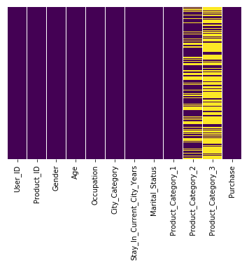

```python
#Clearly categories 2 and 3 are missing a bunch of data

sns.heatmap(train.isnull(),yticklabels=False,cbar=False,cmap='viridis')
```

# [Data Cleanse]

```python
def category_fill(cols):
    """Fills in the column with 0s, form:
    df['column'] = df[['column']].apply(category_fill, axis=1)"""
    Category = cols[0]

    if pd.isnull(Category):
        return 0
    else:
        return Category
```

```python
train['Product_Category_2'] = train[['Product_Category_2']].apply(category_fill, axis=1)
```

```python
train['Product_Category_3'] = train[['Product_Category_3']].apply(category_fill, axis=1)
```

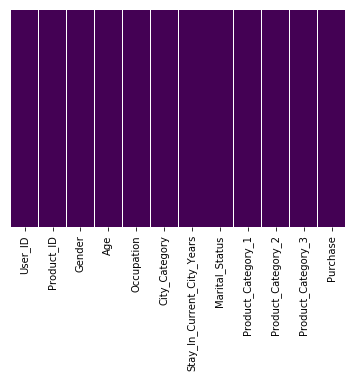

```python
#Missing data filled in with 0s since we cannot infer values for the missing categories
sns.heatmap(train.isnull(),yticklabels=False,cbar=False,cmap='viridis')
```

```python
train_Individuals = pd.DataFrame(train[['User_ID', 'Gender', 'Age', 'Occupation', 'City_Category',
            'Stay_In_Current_City_Years', 'Marital_Status']])
train_Individuals = train_Individuals.drop_duplicates()
train_Individuals.head(5)
```

|  | User_ID | Gender | Age | Occupation | City_Category | Stay_In_Current_City_Years | Marital_Status |
| --- | --- | --- | --- | --- | --- | --- | --- |
| 0 | 1000001 | F | 0-17 | 10 | A | 2 | 0 |
| 4 | 1000002 | M | 55+ | 16 | C | 4+ | 0 |
| 5 | 1000003 | M | 26-35 | 15 | A | 3 | 0 |
| 6 | 1000004 | M | 46-50 | 7 | B | 2 | 1 |
| 9 | 1000005 | M | 26-35 | 20 | A | 1 | 1 |

# Gender Distribution

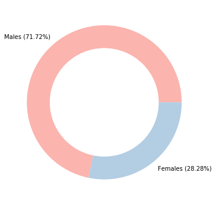

```python
females = (train_Individuals['Gender']=='F').sum()/train_Individuals['Gender'].count()
males = (train_Individuals['Gender']=='M').sum()/train_Individuals['Gender'].count()
size = [males,females]
plt.figure(figsize=(10, 6))

my_circle = plt.Circle((0,0),0.7,color='white')
plt.pie(size, labels=['Males (71.72%)','Females (28.28%)'], colors=Pastel1_7.hex_colors)
p=plt.gcf()
p.gca().add_artist(my_circle)
plt.show()
```

# Age

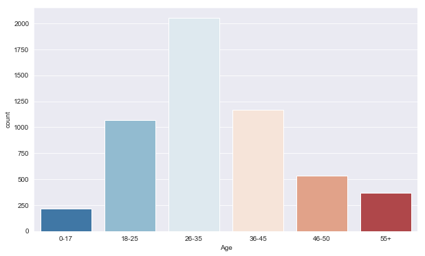

```python
plt.figure(figsize=(10, 6))
sns.countplot(x='Age',order=['0-17','18-25','26-35','36-45','46-50','55+'],data=train_Individuals,palette='RdBu_r')
#Age distribution
```

#### The age distribution above is close to a normal distribution, but we can see it is skewed a bit towards the right. Inferences on why the primary age at which the most purchases were made, can be due to factors that are outside the direct scope of the dataset (such as societal trends, emergence and usage of new tech, 26-35 could be an age where people move into a new home/get things for their children, etc.).

```python
#marriage + age against the purchase amounts?
train_PurchaseTotals = pd.DataFrame(train[['User_ID','Purchase']])
train_PurchaseTotals = pd.DataFrame(train_PurchaseTotals.groupby('User_ID')['Purchase'].sum())
train_summary = pd.merge(train_PurchaseTotals, train_Individuals, on='User_ID', how='outer')

train_summary['Purchase'].iplot(kind='hist',bins=500)
```

[interactive chart not shown]

```python
train_summary.describe()
```

|  | User_ID | Purchase | Occupation | Marital_Status |
| --- | --- | --- | --- | --- |
| count | 5.891000e+03 | 5.891000e+03 | 5891.000000 | 5891.000000 |
| mean | 1.003025e+06 | 8.650166e+05 | 8.153285 | 0.419963 |
| std | 1.743379e+03 | 9.436445e+05 | 6.323140 | 0.493594 |
| min | 1.000001e+06 | 4.668100e+04 | 0.000000 | 0.000000 |
| 25% | 1.001518e+06 | 2.376780e+05 | 3.000000 | 0.000000 |
| 50% | 1.003026e+06 | 5.212130e+05 | 7.000000 | 0.000000 |
| 75% | 1.004532e+06 | 1.119250e+06 | 14.000000 | 1.000000 |
| max | 1.006040e+06 | 1.053691e+07 | 20.000000 | 1.000000 |

```python
# Standardizing/feature scaling to help pull in high outliers? Have to use the same numbers for scaling
# and metric accuracy for test data

#train_summary['Purchase'] = ((train_summary['Purchase'] - 8.650166e+05)/9.436445e+05)
```

```python
# OUTLIER REMOVAL TESTING
#train_summary.max()
#train_summary[train_summary['Purchase']==8699596].index.item()
#train_summary = train_summary.drop(labels=1634,axis=0)
#removed outlier at index 4166, purchase totaling 10536909
#removed outlier at index 1634, purchase totaling 8699596
```

```python
# Finding the amounts per product purchased by each gender for Category 1
#train['Product_Category_1'].value_counts().where(train['Gender']=='F').sort_values()
#train['Product_Category_1'].value_counts().where(train['Gender']=='M').sort_values()

x = [1,2,3,4,5,6,7,8,9,10,11,12,13,14,15,16,17,18,19,20]
#females
y = [140378,23864,20213,0,0,0,0,0,0,0,0,0,0,1523,6290,9828,578,0,0,0]
#males
y2 = [0,0,0,11753,150933,20466,3721,113925,410,5125,24287,3947,5549,0,0,0,0,3125,1603,2550]

trace1 = go.Bar(x=x,y=y,name='Females',marker=dict(color='rgb(55, 83, 109)'))
trace2 = go.Bar(x=x,y=y2,name='Males',marker=dict(color='rgba(219, 64, 82, 0.7)'))
data = [trace1, trace2]

layout = go.Layout(title='Quantity Purchased from Product_Category_1 by Gender',
    xaxis=dict(
        tickfont=dict(size=14,color='rgb(107, 107, 107)'),tickvals=x,
        ticktext=x),
    yaxis=dict(
        title='Count',titlefont=dict(size=16,color='rgb(107, 107, 107)'),
        tickfont=dict(size=14,color='rgb(107, 107, 107)')),
    barmode='group',
    bargap=0.15,
    bargroupgap=0.1
)

fig = go.Figure(data=data, layout=layout)
py.offline.iplot(fig, filename='style-bar')
```

[interactive chart not shown]

```python
# Finding the amounts per product purchased by each gender for Category 2
#train['Product_Category_2'].value_counts().where(train['Gender']=='F').sort_values()
#train['Product_Category_2'].value_counts().where(train['Gender']=='M').sort_values()

x = [1,2,3,4,5,6,7,8,9,10,11,12,13,14,15,16,17,18,19,20]
#females
y = [0,49217,2884,0,0,0,0,0,0,0,0,0,0,55108,37855,43255,13320,0,0,0]
#males
y2 = [0,0,0,25677,26235,16466,626,64088,5693,3043,14134,5528,10531,0,0,0,0,2770,0,0]

trace1 = go.Bar(x=x,y=y,name='Females',marker=dict(color='rgb(55, 83, 109)'))
trace2 = go.Bar(x=x,y=y2,name='Males',marker=dict(color='rgba(219, 64, 82, 0.7)'))
data = [trace1, trace2]

layout = go.Layout(title='Quantity Purchased from Product_Category_2 by Gender',
    xaxis=dict(
        tickfont=dict(size=14,color='rgb(107, 107, 107)'),tickvals=x,
        ticktext=x),
    yaxis=dict(
        title='Count',titlefont=dict(size=16,color='rgb(107, 107, 107)'),
        tickfont=dict(size=14,color='rgb(107, 107, 107)')),
    barmode='group',
    bargap=0.15,
    bargroupgap=0.1
)

fig = go.Figure(data=data, layout=layout)
py.offline.iplot(fig, filename='style-bar')
```

[interactive chart not shown]

```python
#train['Product_Category_3'].value_counts().where(train['Gender']=='F').sort_values()
#train['Product_Category_3'].value_counts().where(train['Gender']=='M').sort_values()

x = [1,2,3, 4, 5, 6,7, 8, 9, 10, 11, 12, 13, 14, 15, 16, 17, 18,19,20]
#females
y = [0,0,613,0,0,0,0,0,0,0,0,0,0,18428,28013,32636,16702,0,0,0]
#males
y2 = [0,0,0,1875,16658,4890,0,4890,12562,11579,1726,1805,9246,5459,0,0,0,0,4629,0,0]

trace1 = go.Bar(x=x,y=y,name='Females',marker=dict(color='rgb(55, 83, 109)'))
trace2 = go.Bar(x=x,y=y2,name='Males',marker=dict(color='rgba(219, 64, 82, 0.7)'))
data = [trace1, trace2]

layout = go.Layout(title='Quantity Purchased from Product_Category_3 by Gender',
    xaxis=dict(
        tickfont=dict(size=14,color='rgb(107, 107, 107)'),tickvals=x,
        ticktext=x),
    yaxis=dict(
        title='Count',titlefont=dict(size=16,color='rgb(107, 107, 107)'),
        tickfont=dict(size=14,color='rgb(107, 107, 107)')),
    barmode='group',
    bargap=0.15,
    bargroupgap=0.1
)

fig = go.Figure(data=data, layout=layout)
py.offline.iplot(fig, filename='style-bar')
```

[interactive chart not shown]

### In all three of these we can see that there are certain products that only females bought, and certain products that only males bought. We can infer that these might be gender-specific products or those geared towards one gender or the other (for example make-up versus tools/hardware).

```python
train = pd.read_csv('train.csv')
```

```python
train['Product_Category_2'] = train[['Product_Category_2']].apply(category_fill, axis=1)
train['Product_Category_3'] = train[['Product_Category_3']].apply(category_fill, axis=1)
```

```python
sex = pd.get_dummies(train['Gender'],drop_first=True,dtype=int)
city = pd.get_dummies(train['City_Category'],drop_first=True,dtype=int)
age = pd.get_dummies(train['Age'],drop_first=True,dtype=int)
occ = pd.get_dummies(train['Occupation'],drop_first=True,dtype=int)
Stay = pd.get_dummies(train['Stay_In_Current_City_Years'],drop_first=True,dtype=int)
```

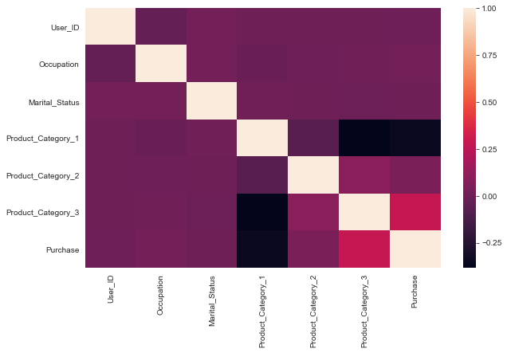

```python
plt.figure(figsize=(10, 6))
sns.heatmap(train.corr())
```

```python
train = pd.concat([train,sex,age,occ,city,Stay],axis=1)
```

```python
train = train.drop(['Gender','City_Category','Age','Occupation','Stay_In_Current_City_Years'],axis=1)
```

```python
train = train.drop(['User_ID','Product_ID'],axis=1)
```

```python
#poly = PolynomialFeatures(degree=3)
```

## Linear Regression

```python
#x_poly = poly.fit_transform(train.drop('Purchase',axis=1))
x_ = train.drop('Purchase',axis=1)
```

```python
y_ = train["Purchase"]
```

```python
X_train, X_test, y_train, y_test = train_test_split(x_, y_, test_size=0.3, random_state=42)
```

```python
logmodel = LinearRegression()
```

```python
#x_poly = poly.fit_transform(X_train)
```

```python
#poly.fit(x_poly, y_train)
```

```python
logmodel.fit(X_train,y_train)
```

```
LinearRegression(copy_X=True, fit_intercept=True, n_jobs=None,
         normalize=False)
```

```python
predictions = logmodel.predict(X_test)
```

```python
predictions
```

```
array([12888.78175994, 12247.51765954,  7258.9994106 , ...,
       10765.80532835, 11881.58323648,  8624.37684424])
```

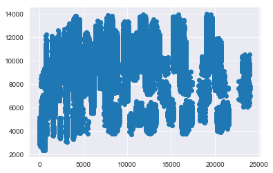

```python
plt.scatter(y_test,predictions)
```

```python
np.sqrt(metrics.mean_squared_error(y_test,predictions))
```

```
4624.191609897273
```

```python
test = pd.read_csv('test.csv')
```

```python
test['Product_Category_2'] = test[['Product_Category_2']].apply(category_fill, axis=1)
```

```python
test['Product_Category_3'] = test[['Product_Category_3']].apply(category_fill, axis=1)
```

```python
test.head()
```

|  | User_ID | Product_ID | Gender | Age | Occupation | City_Category | Stay_In_Current_City_Years | Marital_Status | Product_Category_1 | Product_Category_2 | Product_Category_3 |
| --- | --- | --- | --- | --- | --- | --- | --- | --- | --- | --- | --- |
| 0 | 1000004 | P00128942 | M | 46-50 | 7 | B | 2 | 1 | 1 | 11.0 | 0.0 |
| 1 | 1000009 | P00113442 | M | 26-35 | 17 | C | 0 | 0 | 3 | 5.0 | 0.0 |
| 2 | 1000010 | P00288442 | F | 36-45 | 1 | B | 4+ | 1 | 5 | 14.0 | 0.0 |
| 3 | 1000010 | P00145342 | F | 36-45 | 1 | B | 4+ | 1 | 4 | 9.0 | 0.0 |
| 4 | 1000011 | P00053842 | F | 26-35 | 1 | C | 1 | 0 | 4 | 5.0 | 12.0 |

```python
sex = pd.get_dummies(test['Gender'],drop_first=True,dtype=int)
city = pd.get_dummies(test['City_Category'],drop_first=True,dtype=int)
age = pd.get_dummies(test['Age'],drop_first=True,dtype=int)
occ = pd.get_dummies(test['Occupation'],drop_first=True,dtype=int)
Stay = pd.get_dummies(test['Stay_In_Current_City_Years'],drop_first=True,dtype=int)
```

```python
test = pd.concat([test,sex,city,age,occ],axis=1)
```

```python
test = test.drop(['Gender','City_Category','Age','Occupation','Stay_In_Current_City_Years'],axis=1)
```

```python
test = test.drop(['User_ID','Product_ID'],axis=1)
```

```python
logmodel2 = LinearRegression()
```

```python
logmodel2.fit(x_,y_)
```

```
LinearRegression(copy_X=True, fit_intercept=True, n_jobs=None,
         normalize=False)
```

```python
prediction2 = logmodel2.predict(test)
```

```python
index = [i for i in range(0, len(prediction2))]
```

```python
np.reshape(prediction2,(1,len(prediction2)))
```

```python
test = pd.read_csv('test.csv')
```

```python
y_predictions = pd.DataFrame(data=prediction2,index=index,columns=['Purchase'])
```

```python
b = pd.concat([test,y_predictions], sort=True,axis=1)
```

```python
b=b.drop(['Gender','City_Category','Age','Occupation','Stay_In_Current_City_Years','Marital_Status','Product_Category_1','Product_Category_2','Product_Category_3'],axis=1)
```

```python
np.savetxt("predictions.csv", b,fmt='%s', delimiter=",")
```